# 한국 R 사용자회 - Shiny 앱

##### 원주율(π)

몬테카를로 모의시험 방법으로 원주율 계산 (Shiny App)

[figure not shown]

2022-06-02

##### 실용통계

실용통계 데이터셋 (실행방법: CTRL + 클릭)

[figure not shown]

2022-06-03

##### 숫자 맞추기

기회는 3번, 1~20사이 숫자 맞추기

[figure not shown]

2022-06-04

##### 추론: flexdashboard

가설 검정 - 평균, 비율, 분산에 대한 추론

[figure not shown]

2022-06-05

##### 추론: Shiny

가설 검정 - 평균, 비율, 분산에 대한 추론

[figure not shown]

2022-06-10

##### 확률분포

정규, 이산형, 연속형 분포

[figure not shown]

2022-06-15

##### 회귀분석

선형 회귀 분석

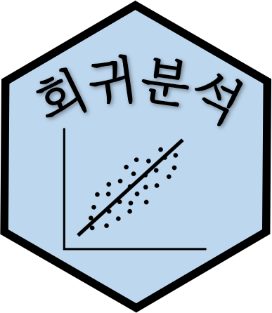

2022-06-16

##### t-분포&정규분포

t-분포와 표준정규분포 특성

[figure not shown]

2022-06-17

##### 중심극한정리

대수의법칙과 중심극한정리

[figure not shown]

2022-06-17

##### 모의실험

동전, 주사위 던지기 ...

[figure not shown]

2022-06-12

##### 예측모형

기계학습 팔머펭귄 성별 예측 시스템

[figure not shown]

2022-06-20

##### 선거

제20대 대통령선거 투표/득표

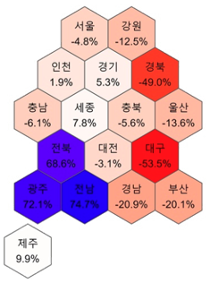

2022-06-13

##### 금융

주택담보대출 모의시험

[figure not shown]

2022-06-19

##### 신경망 모형

분류 문제에 대한 로지스틱 통계 모형 대비 신경망(Neural Network) 모형 이해

[figure not shown]

2022-06-26

##### 이미지 인식

resnet 엔진으로 이미지 내 사물 인식

[figure not shown]

2022-06-25

# 개발도구

[bs4cards](https://bs4cards.djnavarro.net/articles/articles/layouts.html)

# 후원

이 프로그램은 과학기술진흥기금 및 복권기금의 재원으로 운영되고,과학기술정보통신부와 한국과학창의재단의 지원을 받아 수행된 성과물로 우리나라의 과학기술 발전과 사회적 가치 증진에 기여하고 있습니다. 성균관대학교 경제학과, 한밭대학교 창업경영학과에서 장소를 지원해 주셨으며, 대전과학문화거점센터 지원도 받았음을 밝혀둡니다.

[figure not shown]